# Prepare structured (SABAP2) and unstructured data for Hessequa Atlas Area

Katelyn Faulkner

2025-04-23

```r
# Load packages
library(tidyverse) # Data wrangling and visualisation
library(here)      # Relative paths
library(sf)        # Work with spatial data
library(rgbif)     # To request occurrence cubes
library(gcube)     # To create a cube using a bespoke grid
```

# Goal

Load and save structured data of the Hessequa systematic atlasing subproject of the “Southern African Bird Atlas Project 2” (SABAP2).

Load and save unstructured data from GBIF.

SABAP2 data are collected at a pentad resolution (5min x 5min).

The data are prepared both at a pentad resolution, and at quarter degree grid cell resolution. 9 pentads fit into one quarter degree grid cell (15 min x 15 min)

The period 2015-2024 is of interest

# Load data

## Structured data

### Sampling framework

**SABAP2 - Southern African Bird Atlas Project 2 - sampling framework** is downloaded as a geoJSON file from https://sabap2.birdmap.africa/coverage/group/Hssq1.

Follow the instructions on the website to download the file, then save it as a shapefile and store under *./data/raw*.

We read in the dataset.

```r
# Data path and create directory if necessary
data_path <- here::here("data", "raw")
dir.create(data_path, showWarnings = FALSE, recursive = TRUE)
```

```r
# Read SABAP2 Hessequa atlas area pentad grid (5min x 5 min/ 8.2 km x 8.2 km)
HAASFraw <- read_sf(file.path(data_path, "Hessequa_sampling_framework", "Hessequa_sampling_framework.shp"))

# Explore dataframe
glimpse(HAASFraw)
```

```
## Rows: 77
## Columns: 27
## $ pentad       <chr> "3355_2045", "3355_2050", "3355_2100", "3355_2105", "3355…
## $ `full proto` <dbl> 156, 32, 24, 24, 30, 25, 23, 28, 74, 28, 26, 23, 32, 31, …
## $ `full pro_1` <dbl> 521, 153, 144, 146, 126, 125, 141, 141, 302, 147, 133, 14…
## $ `adhoc prot` <dbl> 48, 17, 0, 5, 13, 4, 5, 10, 53, 40, 10, 1, 3, 14, 8, 4, 3…
## $ incidental   <dbl> 0, 0, 0, 0, 0, 0, 0, 0, 0, 0, 0, 0, 0, 0, 0, 0, 0, 0, 0, …
## $ additional   <dbl> 0, 0, 0, 0, 0, 0, 0, 0, 0, 0, 0, 0, 0, 0, 0, 0, 0, 0, 0, …
## $ `2007`       <dbl> 1, 0, 0, 0, 0, 0, 0, 0, 0, 0, 0, 0, 0, 0, 1, 0, 0, 0, 0, …
## $ `2008`       <dbl> 3, 1, 1, 0, 0, 0, 0, 0, 4, 1, 1, 0, 0, 0, 0, 0, 0, 0, 0, …
## $ `2009`       <dbl> 4, 0, 1, 0, 1, 0, 0, 0, 1, 0, 0, 1, 0, 2, 0, 1, 1, 0, 0, …
## $ `2010`       <dbl> 10, 1, 1, 1, 0, 0, 0, 2, 0, 0, 0, 0, 1, 0, 0, 0, 0, 2, 1,…
## $ `2011`       <dbl> 16, 3, 1, 1, 1, 3, 0, 0, 1, 1, 0, 0, 0, 0, 0, 0, 0, 0, 0,…
## $ `2012`       <dbl> 11, 0, 0, 0, 0, 0, 0, 0, 3, 0, 1, 0, 0, 0, 0, 1, 1, 0, 0,…
## $ `2013`       <dbl> 11, 0, 0, 0, 1, 0, 1, 0, 4, 0, 0, 0, 0, 0, 0, 0, 0, 1, 1,…
## $ `2014`       <dbl> 8, 0, 0, 0, 0, 0, 0, 1, 2, 0, 0, 0, 1, 0, 1, 1, 0, 1, 2, …
## $ `2015`       <dbl> 6, 1, 1, 1, 1, 1, 1, 1, 3, 2, 2, 3, 2, 4, 5, 4, 6, 3, 1, …
## $ `2016`       <dbl> 8, 0, 3, 3, 3, 2, 4, 2, 7, 2, 4, 2, 4, 4, 4, 6, 4, 1, 1, …
## $ `2017`       <dbl> 13, 7, 2, 3, 2, 3, 3, 4, 4, 3, 2, 4, 2, 2, 3, 2, 2, 3, 3,…
## $ `2018`       <dbl> 8, 2, 2, 2, 2, 2, 2, 2, 3, 4, 3, 1, 2, 3, 2, 2, 3, 1, 3, …
## $ `2019`       <dbl> 13, 3, 2, 2, 2, 3, 2, 2, 6, 4, 3, 3, 2, 3, 2, 3, 2, 2, 2,…
## $ `2020`       <dbl> 10, 2, 2, 2, 4, 1, 2, 3, 6, 1, 1, 2, 3, 2, 3, 2, 3, 3, 4,…
## $ `2021`       <dbl> 9, 2, 3, 4, 5, 4, 3, 3, 7, 2, 4, 2, 6, 5, 5, 4, 6, 3, 3, …
## $ `2022`       <dbl> 11, 3, 3, 2, 2, 2, 1, 3, 5, 5, 1, 2, 2, 1, 2, 2, 3, 2, 1,…
## $ `2023`       <dbl> 8, 2, 0, 1, 2, 3, 1, 2, 7, 1, 1, 1, 4, 3, 2, 3, 1, 3, 3, …
## $ `2024`       <dbl> 5, 5, 2, 2, 4, 1, 3, 3, 11, 2, 3, 2, 3, 2, 2, 1, 2, 2, 3,…
## $ `2025`       <dbl> 1, 0, 0, 0, 0, 0, 0, 0, 0, 0, 0, 0, 0, 0, 0, 0, 0, 0, 0, …
## $ format       <chr> "geoJSON", "geoJSON", "geoJSON", "geoJSON", "geoJSON", "g…
## $ geometry     <POLYGON [°]> POLYGON ((20.75 -33.91667, ..., POLYGON ((20.8333…
```

### Occurrence data

Occurrence data was downloaded from GBIF.org. Unzip and store folder under *./data/raw*. The SABAP2 dataset was filtered so that only data from the Western Cape (Administrative areas = Western Cape - ZAF.9_1) was downloaded.

Note these data were not obtained as a cube through rgbif, as some manipulation is required to remove adhoc records that is not possible with the filters available.

GBIF.org (17 January 2025) GBIF Occurrence Download https://doi.org/10.15468/dl.95kujb

We read in the dataset.

```r
# Read SABAP2 data as tab delimited
SABAP2WCraw <- read_delim(file.path(data_path,
                                     "0073671-241126133413365",
                                     "occurrence.txt"),
                   delim = "\t",
                   show_col_types = FALSE)

# Explore dataframe
glimpse(SABAP2WCraw)
```

```
## Rows: 2,500,161
## Columns: 223
## $ gbifID                              <dbl> 2348240488, 2348245274, 2348247726…
## $ accessRights                        <lgl> NA, NA, NA, NA, NA, NA, NA, NA, NA…
## $ bibliographicCitation               <lgl> NA, NA, NA, NA, NA, NA, NA, NA, NA…
## $ language                            <lgl> NA, NA, NA, NA, NA, NA, NA, NA, NA…
## $ license                             <chr> "CC_BY_4_0", "CC_BY_4_0", "CC_BY_4…
## $ modified                            <lgl> NA, NA, NA, NA, NA, NA, NA, NA, NA…
## $ publisher                           <chr> "FitzPatrick Institute of African …
## $ references                          <lgl> NA, NA, NA, NA, NA, NA, NA, NA, NA…
## $ rightsHolder                        <lgl> NA, NA, NA, NA, NA, NA, NA, NA, NA…
## $ type                                <lgl> NA, NA, NA, NA, NA, NA, NA, NA, NA…
## $ institutionID                       <chr> "FIAO", "FIAO", "FIAO", "FIAO", "F…
## $ collectionID                        <chr> "SABAP2", "SABAP2", "SABAP2", "SAB…
## $ datasetID                           <lgl> NA, NA, NA, NA, NA, NA, NA, NA, NA…
```

[output cut: 210 more lines]

## Unstructured data

### Download cube (qdgc per year)

Retrieved a species occurrence cube using rgbif. The occurrence cube is at QDGC scale per year. To account for sampling bias, the specification recommends including an occurrence count for a higher taxon, typically the family.

The query excluded SABAP2 data

Data for the Western Cape were selected (level1Gid = ‘ZAF.9_1’)

Note, personal details (usernname, password and email address) have been removed from script below

```r
# yearly cube at qdgc resolution
occ_download_sql(user = "", pwd = "", email = "",
                 "SELECT \"year\",
                 GBIF_EQDGCCode(2, decimalLatitude, decimalLongitude, COALESCE(coordinateUncertaintyInMeters, 1000)) AS qdgcCode,
                 speciesKey,
                 species,
                 family,
                 COUNT(*) AS n,
                 MIN(COALESCE(coordinateUncertaintyInMeters, 1000)) AS minCoordinateUncertaintyInMeters, IF(ISNULL(family), NULL, SUM(COUNT(*)) OVER (PARTITION BY family)) AS familyCount FROM occurrence WHERE class = 'Aves' AND occurrenceStatus = 'PRESENT' AND NOT ARRAY_CONTAINS(issue, 'ZERO_COORDINATE') AND NOT ARRAY_CONTAINS(issue, 'COORDINATE_OUT_OF_RANGE') AND NOT ARRAY_CONTAINS(issue, 'COORDINATE_INVALID') AND NOT ARRAY_CONTAINS(issue, 'COUNTRY_COORDINATE_MISMATCH') AND level1Gid = 'ZAF.9_1' AND speciesKey IS NOT NULL AND decimalLatitude IS NOT NULL AND decimalLongitude IS NOT NULL AND collectionCode != 'SABAP2'
GROUP BY
\"year\",
qdgcCode,
speciesKey,
family,
species ORDER BY
\"year\" ASC,
qdgcCode ASC,
speciesKey ASC")
```

The data are downloaded and stored under *./data/raw*.

**Unstructured bird data Western Cape QGDC cube**: 0002739-250121130708018.zip

GBIF.org (23 January 2025) GBIF Occurrence Download https://doi.org/10.15468/dl.pc226a

We read in the dataset.

```r
# Read in datacube from CSV
birdcubeWCYearQDGC <- read_delim(file.path(data_path,
                                     "0002739-250121130708018", "0002739-250121130708018.csv"),
                   delim = "\t",
                   show_col_types = FALSE)

# Explore dataframe
glimpse(birdcubeWCYearQDGC)
```

```
## Rows: 381,658
## Columns: 8
## $ year                             <dbl> NA, NA, NA, NA, NA, NA, NA, NA, NA, N…
## $ qdgccode                         <chr> "E017S32BB", "E017S32DB", "E017S32DB"…
## $ specieskey                       <dbl> 2494088, 2481173, 2481890, 5229384, 2…
## $ species                          <chr> "Euplectes orix", "Larus dominicanus"…
## $ family                           <chr> "Ploceidae", "Laridae", "Phalacrocora…
## $ n                                <dbl> 1, 1, 1, 1, 1, 1, 1, 1, 1, 2, 1, 1, 1…
## $ mincoordinateuncertaintyinmeters <dbl> 111111, 1000, 1000, 1000, 1000, 1000,…
## $ familycount                      <dbl> 140960, 119336, 78437, 7542, 119336, …
```

### Download occurrence data and create cube (pentad per year)

Cube at pentad resolution not available through rgbif. Therefore, downloaded occurrence data, and created a yearly cube at pentad resolution using gcube.

Occurrence data is downloaded from GBIF.org. Unzip and store folders under *./data/raw*.

Filters were:

Occurrence status = Present

Class = Aves

Year = Between 2015 and 2024

Administrative areas (gadm) = Western Cape - ZAF.9_1

Location: Including co-ordinates

Excluded SABAP2 dataset

**Unstructured bird data Western Cape**: 0000453-250225085111116.zip

GBIF.org (25 February 2025) GBIF Occurrence Download https://doi.org/10.15468/dl.4q36e5

We read in the dataset.

```r
# Read unstructured data as tab delimited
birdsWCraw<- read_delim(file.path(data_path,
                                     "0000453-250225085111116",
                                     "occurrence.txt"),
                   delim = "\t",
                   show_col_types = FALSE)
# Explore dataframe
glimpse(birdsWCraw)
```

```
## Rows: 1,461,992
## Columns: 223
## $ gbifID                              <dbl> 2249766828, 2249766824, 2249766841…
## $ accessRights                        <lgl> NA, NA, NA, NA, NA, NA, NA, NA, NA…
## $ bibliographicCitation               <lgl> NA, NA, NA, NA, NA, NA, NA, NA, NA…
## $ language                            <lgl> NA, NA, NA, NA, NA, NA, NA, NA, NA…
## $ license                             <chr> "CC_BY_4_0", "CC_BY_4_0", "CC_BY_4…
## $ modified                            <dttm> NA, NA, NA, NA, NA, NA, NA, NA, N…
## $ publisher                           <chr> "The International Barcode of Life…
## $ references                          <chr> "https://boldsystems.org/index.php…
## $ rightsHolder                        <chr> NA, NA, NA, NA, NA, NA, NA, NA, NA…
## $ type                                <lgl> NA, NA, NA, NA, NA, NA, NA, NA, NA…
## $ institutionID                       <lgl> NA, NA, NA, NA, NA, NA, NA, NA, NA…
## $ collectionID                        <lgl> NA, NA, NA, NA, NA, NA, NA, NA, NA…
## $ datasetID                           <lgl> NA, NA, NA, NA, NA, NA, NA, NA, NA…
```

[output cut: 210 more lines]

Create a cube from downloaded occurrence data

```r
# select columns required
birdsWC<- birdsWCraw %>% select (c('year', 'month', 'family', 'speciesKey', 'species', 'decimalLatitude', 'decimalLongitude', 'coordinateUncertaintyInMeters'))
```

```r
# calculate the pentad based on co-ordinates and create a pentad column
# Note a function has also been written to do this, but is not implemented here

birdsWC<-birdsWC %>% separate(decimalLatitude, c("degreesLat", "otherLat"), "\\.", remove = FALSE)%>%
  mutate(otherLat = (as.numeric(paste0("0.", otherLat)))*60) %>%
  mutate(otherLat = sprintf('%02d', plyr::round_any(otherLat, 5, floor))) %>%
mutate(degreesLat = gsub("-","",degreesLat))  %>%
  unite("pentadLat", degreesLat:otherLat, remove = TRUE, sep = "")
birdsWC<-birdsWC %>% separate(decimalLongitude, c("degreesLong", "otherLong"), "\\.", remove = FALSE)%>%
  mutate(otherLong = (as.numeric(paste0("0.", otherLong)))*60) %>%
  mutate(otherLong = sprintf('%02d', (plyr::round_any(otherLong, 5, floor)))) %>%
mutate(degreesLong = gsub("-","",degreesLong))  %>%
  unite("pentadLong", degreesLong:otherLong, remove = TRUE, sep = "")
birdsWC<-birdsWC %>% unite("pentad", c(pentadLat,pentadLong), sep = "_", remove = TRUE)
```

Prepare data for gcube

```r
# add time point for each observation based on year
birdsWC<- birdsWC %>% mutate (time_point = case_when(
  year == 2015  ~ 1,
  year == 2016  ~ 2,
  year == 2017  ~ 3,
  year == 2018  ~ 4,
  year == 2019  ~ 5,
  year == 2020  ~ 6,
  year == 2021  ~ 7,
  year == 2022  ~ 8,
  year == 2023  ~ 9,
  year == 2024  ~ 10,
))

Hpentads<-unique(HAASFraw$pentad) # pentads in Hessequa atlas area

# subset to only include records from Hessequa atlas area, remove NA speciesKey, Assign NA coordinateUncertaintyInMeters to '1000m'
birdsHAA <- birdsWC %>% filter(birdsWC$pentad %in% Hpentads) %>%
  drop_na(speciesKey) %>% replace_na(list(coordinateUncertaintyInMeters = 1000))
```

```r
# create sf object
birdsHAAsf <- st_as_sf(x = birdsHAA,
               coords = c('decimalLongitude', 'decimalLatitude'), crs = st_crs(HAASFraw))
```

```r
# reproject to a flat co-ordinate reference system
birdsHAAsfreproj <- st_transform(birdsHAAsf, crs = "EPSG:2049") # EPSG:2049 is ideal for Hessequa Atlas Area

HAASFrawReproj<-st_transform(HAASFraw, crs = "EPSG:2049")
```

```r
# create a nested dataframe in the format required to produce multi-species cube
birdsHAAdf<-birdsHAAsfreproj %>% group_by(speciesKey, species, family) %>% nest(.key = "observations") %>% add_column(grid = rep(list(HAASFrawReproj), length(unique(birdsHAAsfreproj$speciesKey))), id_col = rep("pentad", length(unique(birdsHAAsfreproj$speciesKey))), seed = rep (NA, length(unique(birdsHAAsfreproj$speciesKey))), aggregate = rep (TRUE, length(unique(birdsHAAsfreproj$speciesKey))), randomisation= rep("uniform", length(unique(birdsHAAsfreproj$speciesKey)))) %>% ungroup()
```

```r
# create cube
birdGcubeHAAYearPentad<-map_grid_designation(df = birdsHAAdf, nested = FALSE)
```

```
##  ■■■■■■                            17% |  ETA: 14s
```

```
##  ■■■■■■■■■■■■                      37% |  ETA: 10s
```

```
##  ■■■■■■■■■■■■■■■■■■                57% |  ETA:  7s
```

```
##  ■■■■■■■■■■■■■■■■■■■■■■■■          76% |  ETA:  4s
```

```
##  ■■■■■■■■■■■■■■■■■■■■■■■■■■■■■■    98% |  ETA:  0s
```

structure cube in the same way as rgbif

```r
birdcubeHAAYearPentad<-birdGcubeHAAYearPentad %>%filter(n != 0) %>% mutate (year = case_when(
  time_point == 1 ~ 2015,
  time_point == 2  ~ 2016,
  time_point == 3  ~ 2017,
  time_point == 4  ~ 2018,
  time_point == 5  ~ 2019,
  time_point == 6 ~ 2020,
  time_point == 7  ~ 2021,
  time_point == 8  ~ 2022,
  time_point == 9  ~ 2023,
  time_point == 10 ~ 2024,
)) %>% select(family:species, pentad:min_coord_uncertainty, year) %>% rename(mincoordinateuncertaintyinmeters = min_coord_uncertainty)
```

# Subset datasets

Select Hessequa Atlas Area grid cells, data falling into correct time period (2015-2024), and where full protocol was used for surveys (i.e., adhoc records in SABAP2 are removed). From cubes remove records with a minimum con-ordinate uncertainty of > 8 km for pentads and 27 km for qdgc

## SABAP2 data for Western Cape

Select cells that fall into Hessequa Atlas Area

Select data from years between 2015 and 2024

Select records from events where full sampling protocol was followed (i.e., adhoc sampling removed)

Create a column called ‘pentad’

Add a column with QDGC information

```r
# subset data to include years between 2015 and 2024
SABAP2WC<-SABAP2WCraw %>% filter(year >= 2015 & year <=2024)

# subset data to include only full protocol data
SABAP2WC<-SABAP2WC %>% filter(grepl("fullprot", SABAP2WC$occurrenceID, fixed = TRUE))

# subset data to only include records from Hessequa atlas area
Hpentads<-unique(HAASFraw$pentad) # pentads in Hessequa atlas area
SABAP2HAA <- SABAP2WC %>% filter(SABAP2WC$verbatimLocality %in% Hpentads)

# create new column called pentad
SABAP2HAA <- SABAP2HAA  %>%
  mutate(pentad = verbatimLocality)

# create new column called qdgccode
SABAP2HAA <- SABAP2HAA  %>%
  separate(locationRemarks, into = c('Long', 'Lat', 'Code'), sep = c(2,4), remove = FALSE) %>%
mutate(Long = paste0("S", Long))%>%
  mutate(Lat = paste0("E0", Lat))%>%
  unite(qdgccode, c(Lat,Long,Code), remove = TRUE, sep = "")
```

## Sampling framework data for Hessequa Atlas Area

Select data from years between 2015 and 2024

Calculate number of full protocol sampling events

Add a column with QDGC information. Need to use a function get_qdgcCode() to convert decimal degree co-ordinates to QDGC

```r
# Function to get quarter degree grid cell codes from decimal co-ordinates

get_qdgcCode <- function(lat, lon) {
  dirLon<-lon < 0 # true if longitude is negative
  dirLat<-lat < 0 # true if latitude is negative

  DegLonCod<-ifelse(dirLon == TRUE, "W", "E") # assign east/west
  DegLatCod<-ifelse(dirLat == TRUE, "S", "N") # assign north/south

  DegLon <- ifelse(dirLon == TRUE, -1*ceiling(lon), floor(lon)) # extract the integer from longitude (needs to be positive)
  DegLat <- ifelse(dirLat == TRUE, -1*ceiling(lat), floor(lat)) # extract the integer from latitude (needs to be positive)

  declat<-as.numeric(paste0("0.", unlist(stringr::str_split(lat, "\\."))[2])) # extract the fractional part of latitude
  declon<-as.numeric(paste0("0.", unlist(stringr::str_split(lon, "\\."))[2])) # extract the fractional part of longitude

  # Determine first code based on fractional portions

  DegCode<-ifelse(declat < 0.5 & declon < 0.5, "A",
         ifelse(declat < 0.5 & declon > 0.5, "B",
         ifelse(declat > 0.5 & declon < 0.5, "C", "D")))

  # Determine second code based on fractional portions

  DegCode<-ifelse(declat < 0.5 & declon < 0.5, "A",
                  ifelse(declat < 0.5 & declon > 0.5, "B",
                         ifelse(declat > 0.5 & declon < 0.5, "C", "D")))


  if(DegCode == "A"){
    QDegCode<-ifelse(declat < 0.25 & declon < 0.25, "A",
           ifelse(declat < 0.25 & declon > 0.25, "B",
                  ifelse(declat > 0.25 & declon < 0.25, "C", "D")))
  }

 if(DegCode == "B"){
   QDegCode<-ifelse(declat < 0.25 & declon < 0.75, "A",
           ifelse(declat < 0.25 & declon > 0.75, "B",
                  ifelse(declat > 0.25 & declon < 0.75, "C", "D")))
  }

  if(DegCode == "C"){
    QDegCode<-ifelse(declat < 0.75 & declon < 0.25, "A",
           ifelse(declat < 0.75 & declon > 0.25, "B",
                  ifelse(declat > 0.75 & declon < 0.25, "C", "D")))
  }

  if(DegCode == "D"){
    QDegCode<-ifelse(declat < 0.75 & declon < 0.75, "A",
           ifelse(declat < 0.75 & declon > 0.75, "B",
                  ifelse(declat > 0.75 & declon < 0.75, "C", "D")))
  }

  # Construct QDGC string

  paste0(DegLonCod, '0', DegLon, DegLatCod, DegLat, DegCode, QDegCode)

  }
```

```r
# subset data to include years between 2015 and 2024
HAASF<-HAASFraw %>% select(!(c('full proto':'2014','2025')))

# calculate number of full sampling protocols per year
HAASF<-HAASF %>%
  rowwise() %>%
  mutate(fullprotocol = sum(c_across('2015':'2024')))

# get co-ordinates of points in each pentad
HAASFcentroids <- st_centroid(HAASF)
HAASFcoords<-st_coordinates(HAASFcentroids)

# use get_qdgcCode function to get qdgc codes from co-ordinates
HAASF$qdgccode<-apply(HAASFcoords[,c('Y','X')], 1, function(y) get_qdgcCode(y['Y'],y['X']))
```

## Bird occurrence cube for Western Cape at QDGC

Select data from years between 2015 and 2024

Exclude data that have mincoordinateuncertaintyinmeters > 27000

Select data from QDGC that include Hessequa Atlas Area

```r
# subset cube to only include records between 2015 and 2024
birdcubeWCYearQDGC <- birdcubeWCYearQDGC %>% filter(year >= 2015 & year <=2024)

# Subset data to only include records with min co-ordinate uncertainty of <= 27km
birdcubeWCYearQDGC <- birdcubeWCYearQDGC %>% filter(mincoordinateuncertaintyinmeters <=27000)

# subset cube to only include QDGC from Hessequa atlas area

HAAQDGC<-unique(HAASF$qdgccode) # QDGC in Hessequa atlas area

birdcubeHAAYearQDGC <- birdcubeWCYearQDGC %>% filter(birdcubeWCYearQDGC$qdgccode %in% HAAQDGC)
```

## Bird occurrence cube for Western Cape at pentads

Exclude data that have mincoordinateuncertaintyinmeters > 8 km

```r
# Subset data to only include records with min co-ordinate uncertainty of <= 8 km
birdcubeHAAYearPentad <- birdcubeHAAYearPentad %>% filter(mincoordinateuncertaintyinmeters <=8000)
```

# Visualise data

## At QDGC scale

QDGC geometry is downloaded as a GeoPackage from https://zenodo.org/records/4457815. Download the file, unzip, and save it under *./data/raw*.

Read in QDGC geometry

```r
# Read QDGC grid
QDGC_sf <- read_sf(file.path(data_path, "qdgc_south africa", "qdgc_south africa.gpkg"), layer = "tbl_qdgc_02")

# Explore dataframe
glimpse(QDGC_sf)
```

```
## Rows: 8,700
## Columns: 7
## $ qdgc             <chr> "E016S46CD", "E016S46CB", "E016S46AD", "E016S46AB", "…
## $ level_qdgc       <int> 2, 2, 2, 2, 2, 2, 2, 2, 2, 2, 2, 2, 2, 2, 2, 2, 2, 2,…
## $ cellsize_degrees <dbl> 0.25, 0.25, 0.25, 0.25, 0.25, 0.25, 0.25, 0.25, 0.25,…
## $ lon_center       <dbl> 16.375, 16.375, 16.375, 16.375, 16.375, 16.375, 16.37…
## $ lat_center       <dbl> -46.875, -46.625, -46.375, -46.125, -45.875, -45.625,…
## $ area_km2         <dbl> 529.6697, 532.1011, 534.5220, 536.9325, 539.3325, 541…
## $ geom             <MULTIPOLYGON [°]> MULTIPOLYGON (((16.25 -47, ..., MULTIPOL…
```

### Sampling framework data for Hessequa Atlas Area

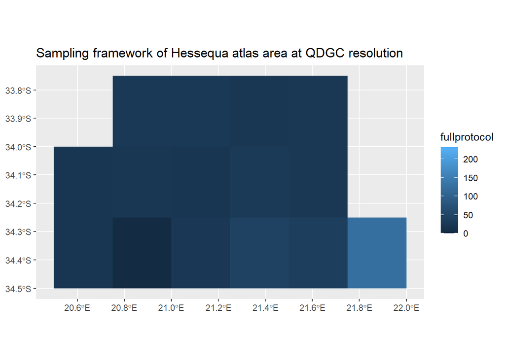

```r
# Remove geometry of sampling framework
HAASFDF<-sf::st_drop_geometry(HAASF)

# Add qdgc geometry of sampling framework by taking an inner join
HAASFQDGC_sf <- QDGC_sf %>%
  inner_join(HAASFDF %>%
             group_by(qdgccode) %>%
            summarise_at(vars('2015':'2024', 'fullprotocol'), sum, na.rm = TRUE),
             by = join_by(qdgc==qdgccode)) %>%
  st_sf(sf_column_name = "geom")

# Visualise spatial distribution of sampling framework
QDGC_sf %>%
 inner_join(HAASFDF,
            group_by(qdgccode) %>%
            summarise_at(vars('2015':'2024', 'fullprotocol'), sum, na.rm = TRUE), by = join_by(qdgc==qdgccode)) %>%
  ggplot() +
    geom_sf(aes(fill = fullprotocol), col = alpha("white", 0)) +
    ggtitle("Sampling framework of Hessequa atlas area at QDGC resolution")
```

Plot shows at a quarter degree grid cell resolution the number of full protocol surveys performed in the Hessequa Atlas Area

### SABAP 2 data for Hessequa Atlas Area

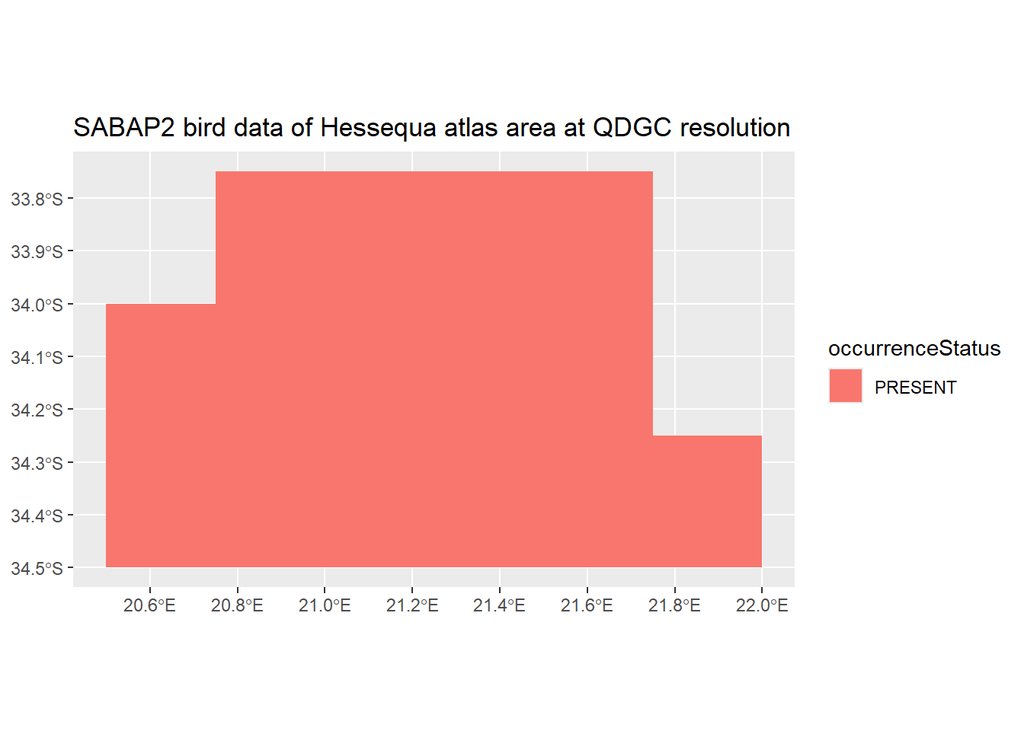

```r
# Add qdgc geometry by taking an inner join
SABAP2HAAQDGC_sf <-  QDGC_sf %>%
  inner_join(SABAP2HAA, by = join_by(qdgc==qdgccode)) %>%
  st_sf(sf_column_name = "geom")

# Visualise spatial distribution of structured data
QDGC_sf %>%
  inner_join(SABAP2HAA %>%
              filter(occurrenceStatus == "PRESENT") %>%
              distinct(occurrenceStatus, qdgccode),
            by = join_by(qdgc==qdgccode)) %>%
  ggplot() +
    geom_sf(aes(fill = occurrenceStatus), col = alpha("white", 0)) +
    ggtitle("SABAP2 bird data of Hessequa atlas area at QDGC resolution")
```

Plot shows the grid cells (at quarter degree grid cell resolution) in which birds have been recorded through SABAP2 in the Hessequa Atlas Area

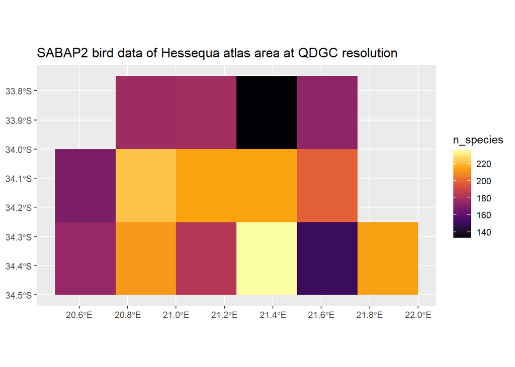

```r
# Visualise spatial distribution of structured data as number of species
QDGC_sf %>%
  inner_join(SABAP2HAA %>%
              filter(occurrenceStatus == "PRESENT") %>%
              group_by(qdgccode) %>%
              summarise(n_species = n_distinct(species), .groups = "drop"),  by = join_by(qdgc==qdgccode)) %>%
  ggplot() +
    geom_sf(aes(fill = n_species), col = alpha("white", 0)) +
  scale_fill_viridis_c(option = "inferno") +
    ggtitle("SABAP2 bird data of Hessequa atlas area at QDGC resolution")
```

Plot shows the number of bird species recorded in grid cells (at quarter degree grid cell resolution) through SABAP2 in the Hessequa Atlas Area

### Bird occurrence cube for Hessequa Atlas Area

```r
# Add qdgc geometry by taking an inner join
birdcubeHAAYearQDGC_sf <- QDGC_sf %>%
  inner_join(birdcubeHAAYearQDGC, by = join_by(qdgc==qdgccode)) %>%
  st_sf(sf_column_name = "geom")
```

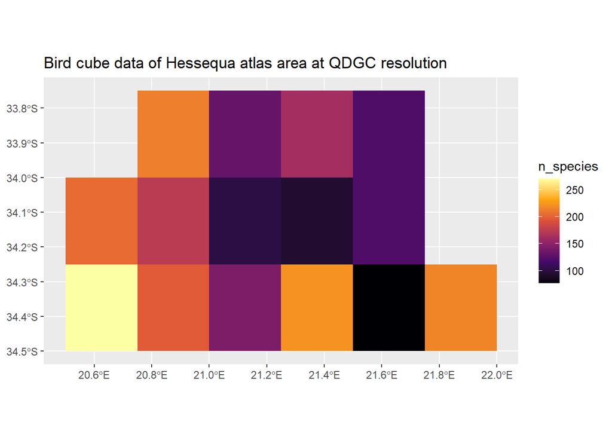

```r
# Visualise spatial distribution data cube as number of species
QDGC_sf %>%
  inner_join(birdcubeHAAYearQDGC %>%
              group_by(qdgccode) %>%
              summarise(n_species = n_distinct(species), .groups = "drop"),
            by = join_by(qdgc==qdgccode)) %>%
  ggplot() +
    geom_sf(aes(fill = n_species), col = alpha("white", 0)) +
    scale_fill_viridis_c(option = "inferno") +
    ggtitle("Bird cube data of Hessequa atlas area at QDGC resolution")
```

Plot shows the number of species recorded in the unstructured data in the Hessequa Atlas Area at a QDGC resolution

## At pentad scale

### Sampling framework data for Hessequa Atlas Area

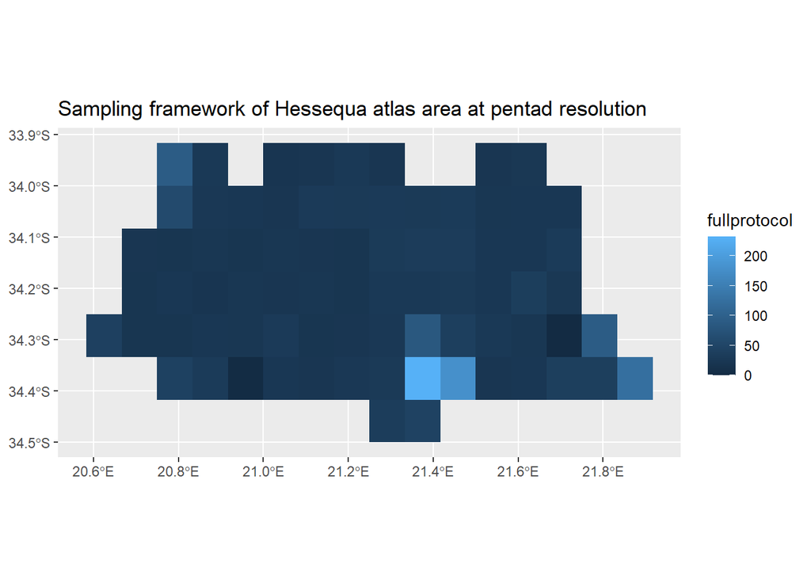

```r
# Visualise spatial distribution sampling framework
HAASF %>%
  ggplot() +
    geom_sf(aes(fill = fullprotocol),
            col = alpha("white", 0)) +
    ggtitle("Sampling framework of Hessequa atlas area at pentad resolution")
```

Plot shows at a pentad resolution the number of full protocol surveys performed in the Hessequa Atlas Area. There are 77 grid cells, and there have been surveys in 76 of them.

### SABAP 2 data for Hessequa Atlas Area

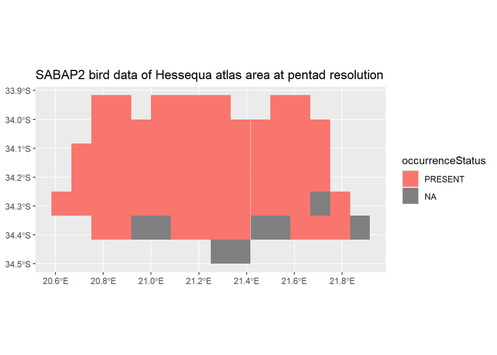

```r
# Add geometry of sampling framework by taking an inner join
SABAP2HAAPentad_sf <- HAASF %>%
  inner_join(SABAP2HAA, by = join_by(pentad)) %>%
  st_sf(sf_column_name = "geometry")

# Visualise spatial distribution of structured data
HAASF %>%
  left_join(SABAP2HAA %>%
              filter(occurrenceStatus == "PRESENT") %>%
              distinct(occurrenceStatus, pentad),
            by = join_by(pentad)) %>%
  ggplot() +
    geom_sf(aes(fill = occurrenceStatus), col = alpha("white", 0)) +
    ggtitle("SABAP2 bird data of Hessequa atlas area at pentad resolution")
```

Plot shows the grid cells (at pentad resolution) in which birds have been recorded through SABAP2 in the Hessequa Atlas Area. Birds have been recorded in 69 of the 77 grid cells (surveys in 76)

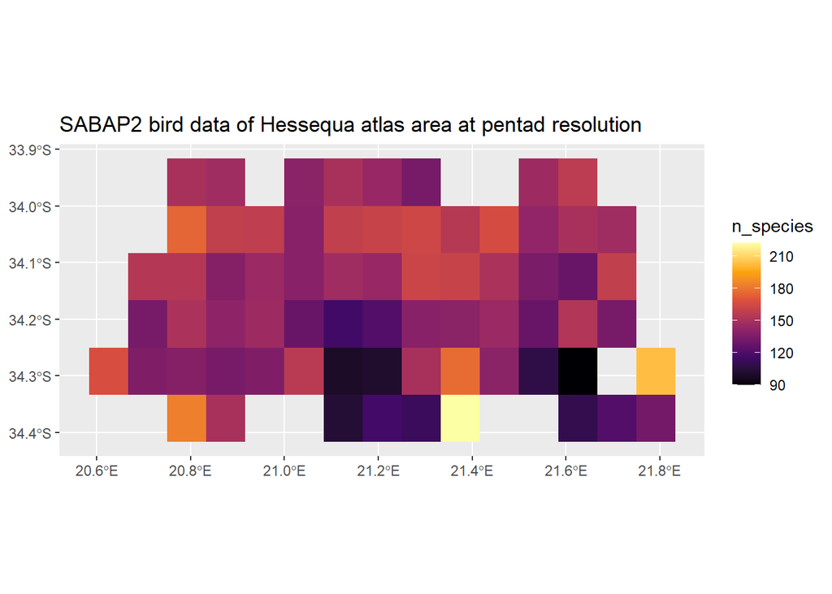

```r
# Visualise spatial distribution of structured data as number of species
HAASF %>%
  inner_join(SABAP2HAA %>%
              filter(occurrenceStatus == "PRESENT") %>%
              group_by(pentad) %>%
              summarise(n_species = n_distinct(species), .groups = "drop"),  by = join_by(pentad)) %>%
  ggplot() +
    geom_sf(aes(fill = n_species), col = alpha("white", 0)) +
  scale_fill_viridis_c(option = "inferno") +
    ggtitle("SABAP2 bird data of Hessequa atlas area at pentad resolution")
```

Plot shows the number of bird species recorded in grid cells (at pentad resolution) through SABAP2 in the Hessequa Atlas Area

### Bird occurrence cube for Hessequa Atlas Area

```r
# Add geometry of sampling framework by taking an inner join
birdcubeHAAYearPentad_sf <- HAASF %>%
  inner_join(birdcubeHAAYearPentad, by = join_by(pentad)) %>%
  st_sf(sf_column_name = "geometry")
```

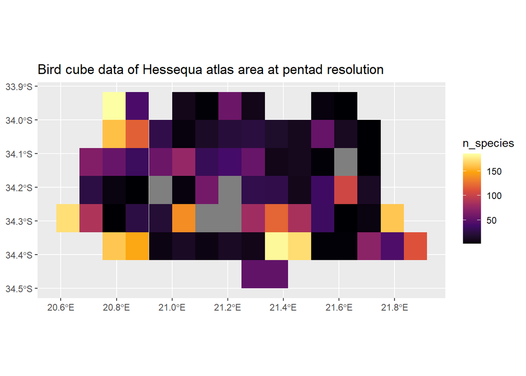

```r
# Visualise spatial distribution data cube as number of species
HAASF %>%
  left_join(birdcubeHAAYearPentad %>%
              group_by(pentad) %>%
              summarise(n_species = n_distinct(species), .groups = "drop"),
            by = join_by(pentad)) %>%
  ggplot() +
    geom_sf(aes(fill = n_species), col = alpha("white", 0)) +
    scale_fill_viridis_c(option = "inferno") +
    ggtitle("Bird cube data of Hessequa atlas area at pentad resolution")
```

Plot shows the number of bird species recorded in grid cells (at pentad resolution) through unstructured sampling in the Hessequa Atlas Area

# Write out data

We write out the data for exploration and analysis.

```r
out_path <- here::here("data", "interim")
dir.create(out_path, showWarnings = FALSE, recursive = TRUE)

# Structured data at QDGC scale
write_sf(SABAP2HAAQDGC_sf,
         file.path(out_path, "SABAP2_QDGC_HAA_data.gpkg"))
write_sf(HAASFQDGC_sf,
         file.path(out_path, "sampling_framework_SABAP2_QDGC.gpkg"))

# Structured data at pentad scale
write_sf(SABAP2HAAPentad_sf,
         file.path(out_path, "SABAP2_Pentad_HAA_data.gpkg"))
write_sf(HAASF,
         file.path(out_path, "sampling_framework_SABAP2_pentad.gpkg"))

# Unstructured data at QDGC scale
write_sf(birdcubeHAAYearQDGC_sf,
         file.path(out_path, "birdcube_QDGC_year_HAA.gpkg"))

# Unstructured data at pentad scale
write_sf(birdcubeHAAYearPentad_sf,
         file.path(out_path, "birdcube_Pentad_year_HAA.gpkg"))
```